# USA Covid Data

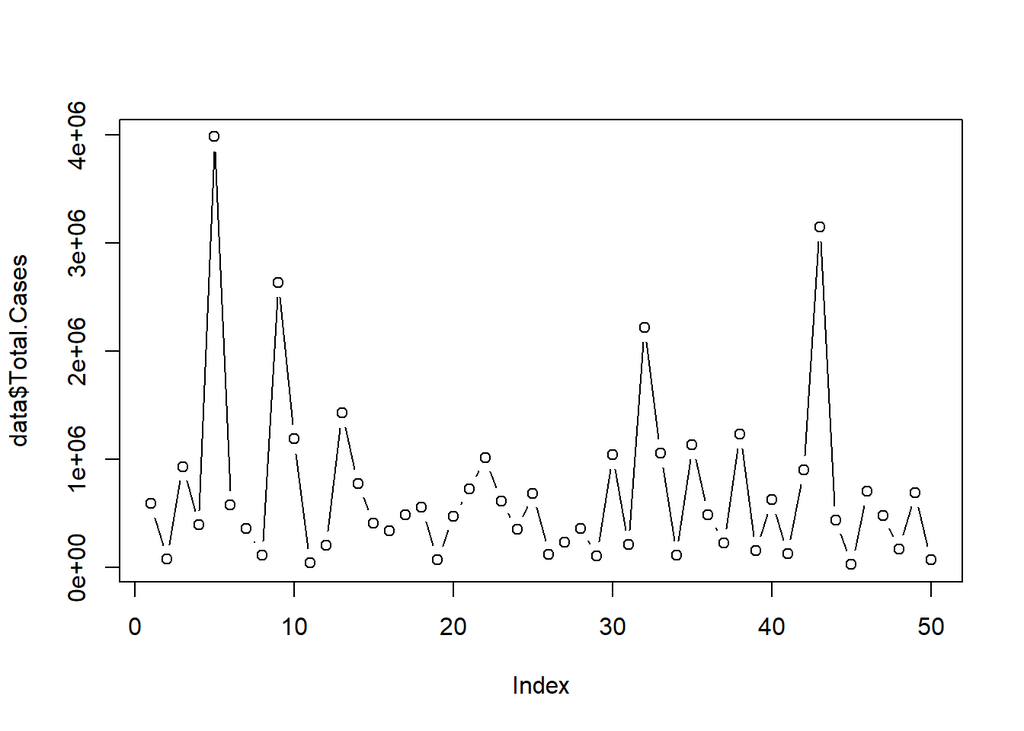

```r
plot(data$Total.Cases, type = 'b')
```

Pie chartS:

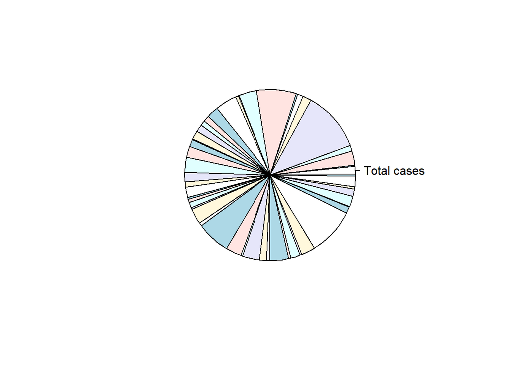

```r
pie(data$Total.Cases, labels = 'Total cases')
```

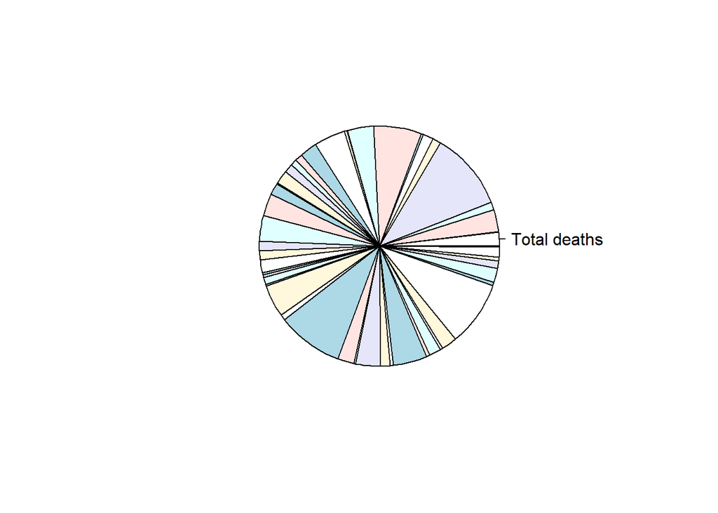

```r
pie(data$Total.Deaths, labels = 'Total deaths')
```

Cleveland Dot Charts:

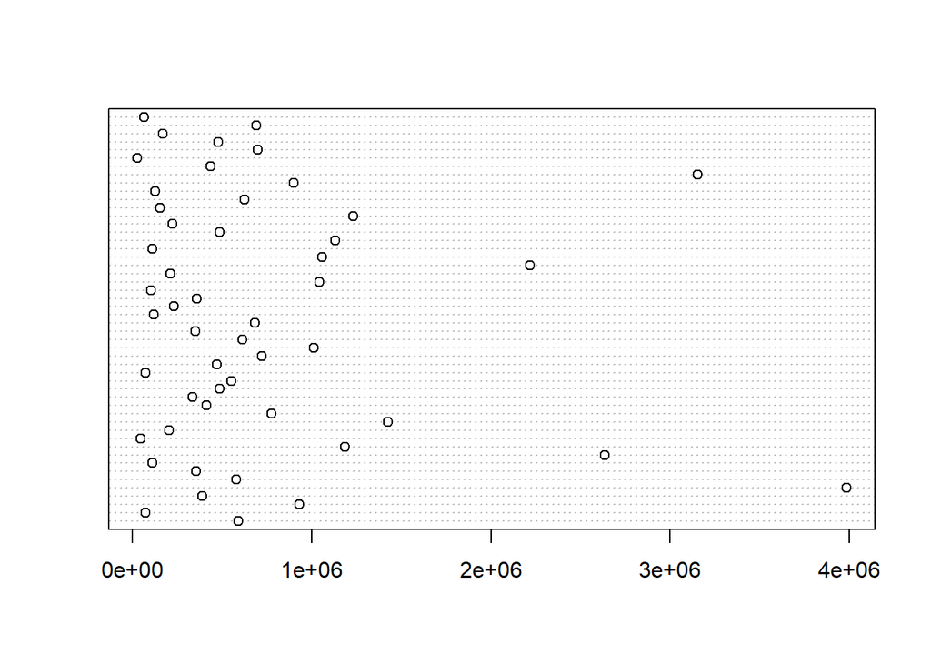

```r
dotchart(data$Total.Cases)
```

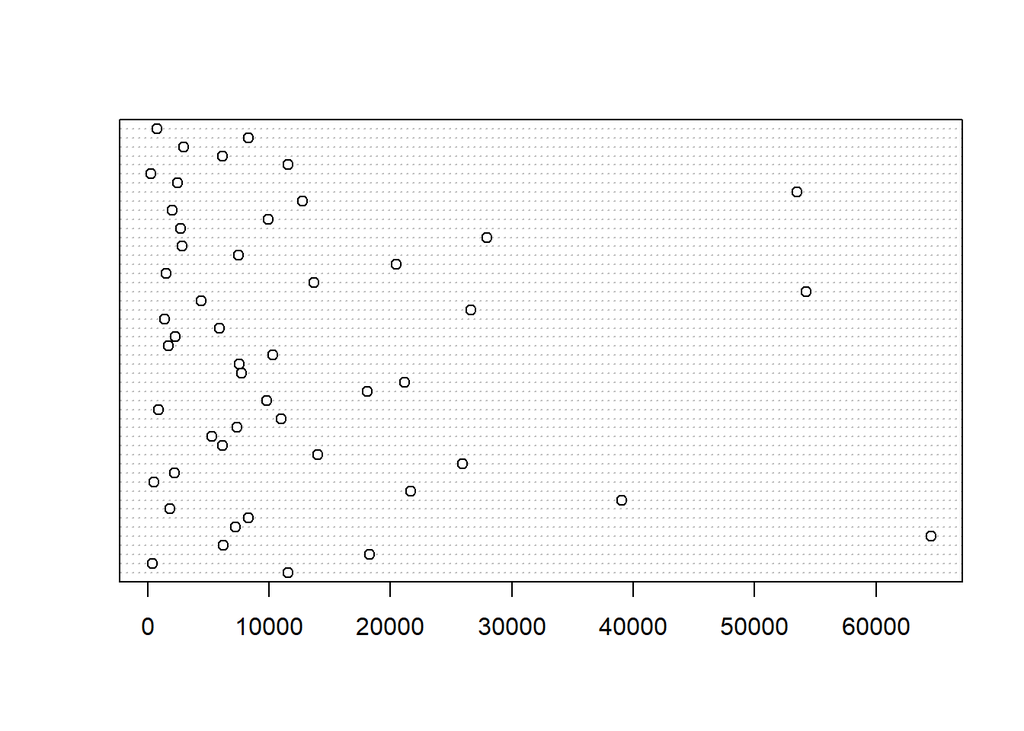

```r
dotchart(data$Total.Deaths)
```

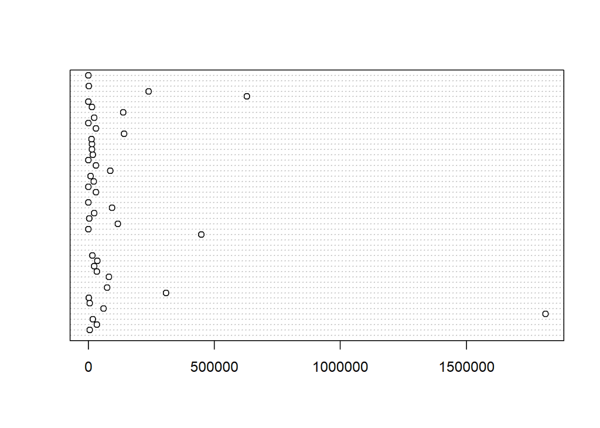

```r
dotchart(data$Active.Cases)
```

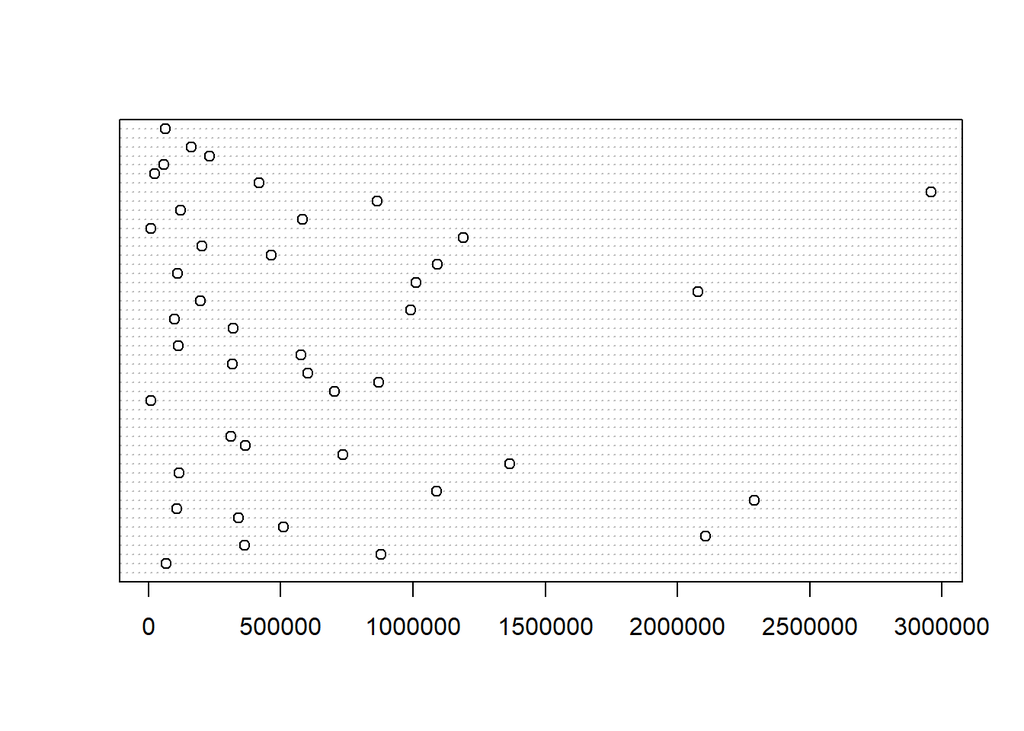

```r
dotchart(data$Total.Recovered)
```

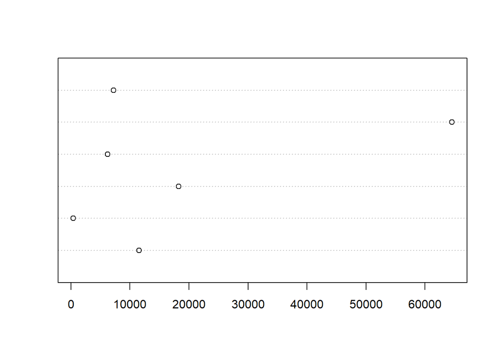

```r
data.mat=head(as.matrix(data$Total.Deaths))
dotchart(head(data$Total.Deaths))
```

Use the t() command to transpose the matrix and produce your dot plot:

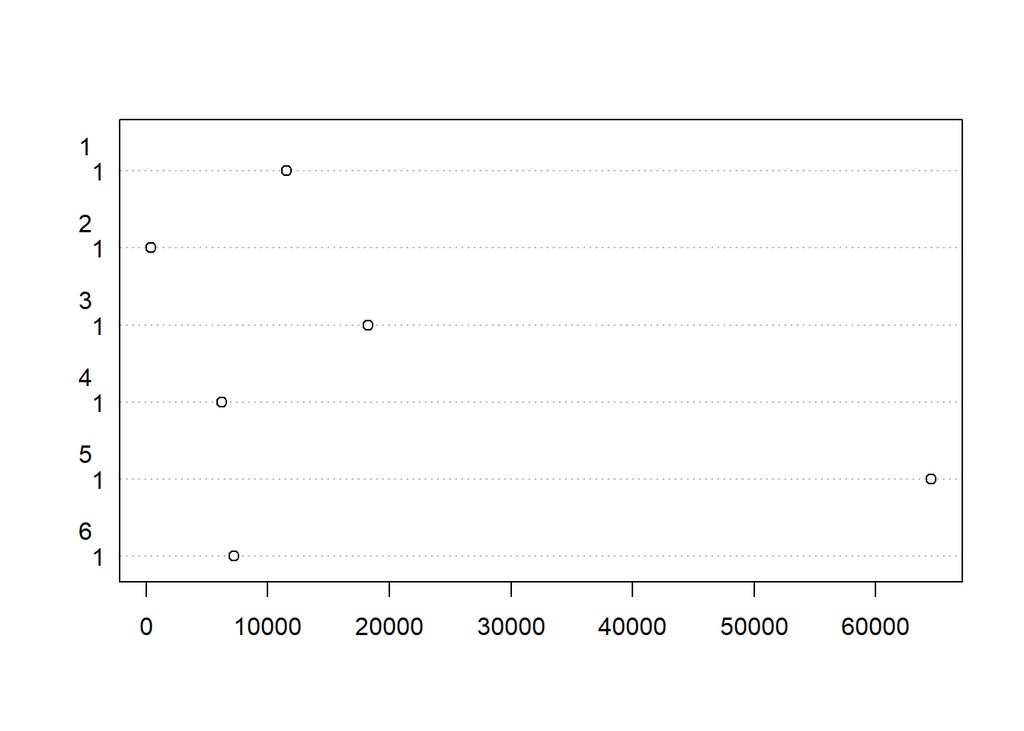

```r
dotchart(t(data.mat))
```

Bar charts: The bar chart is suitable for showing data that fall into discrete categories.

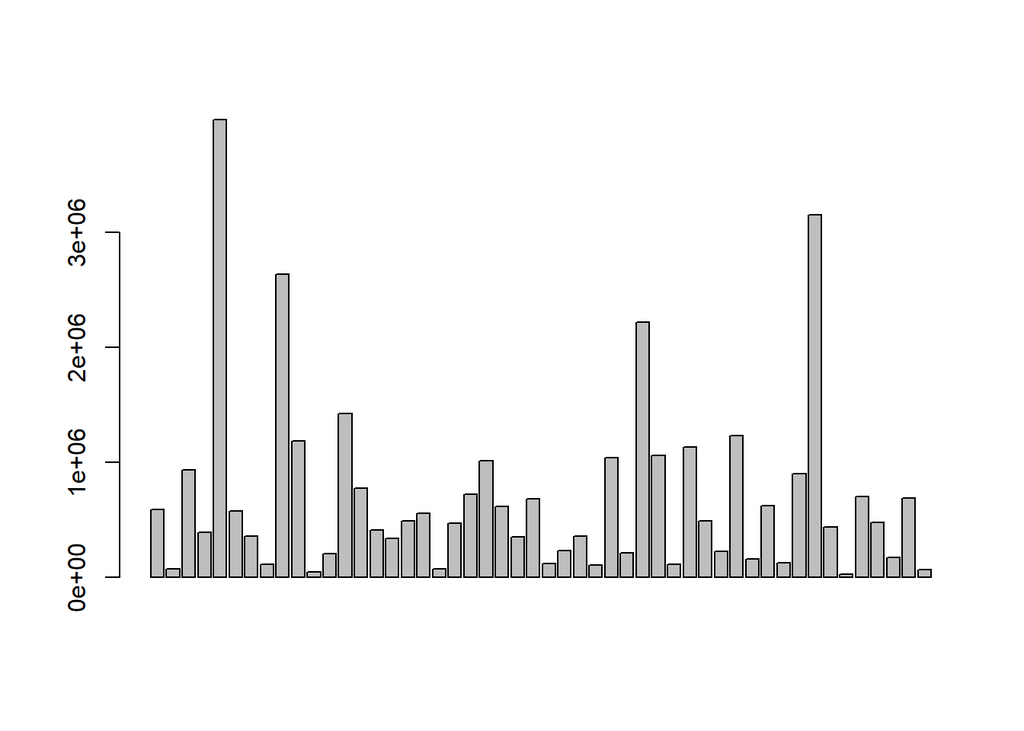

```r
barplot(data$Total.Cases)
```

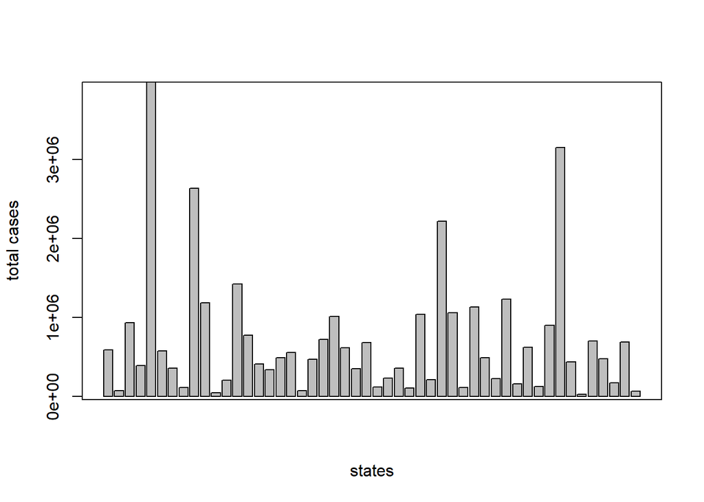

```r
barplot(data$Total.Cases)
title(xlab = 'states', ylab = 'total cases')
box()
```

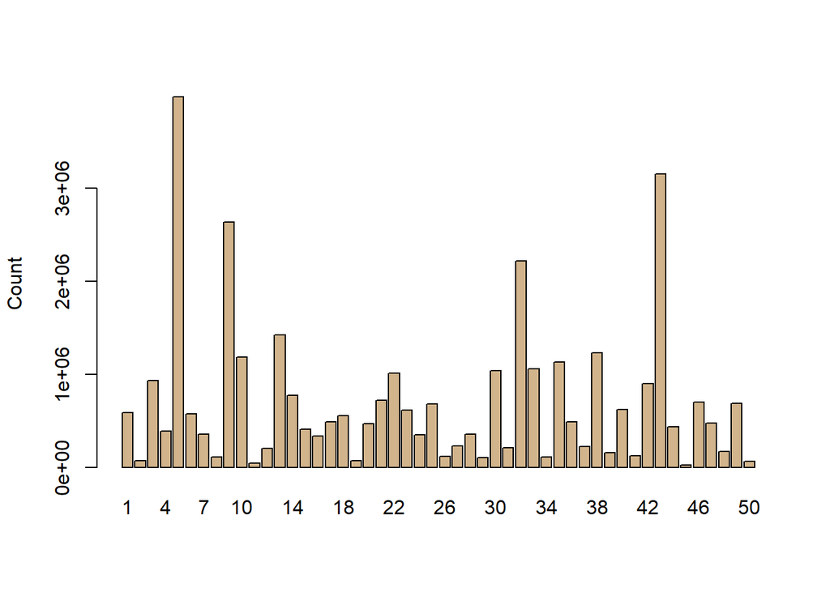

```r
barplot(data$Total.Cases, names = row.names(data), ylab = 'Count' ,
col = 'tan')
```

Multiple Category Bar Charts:

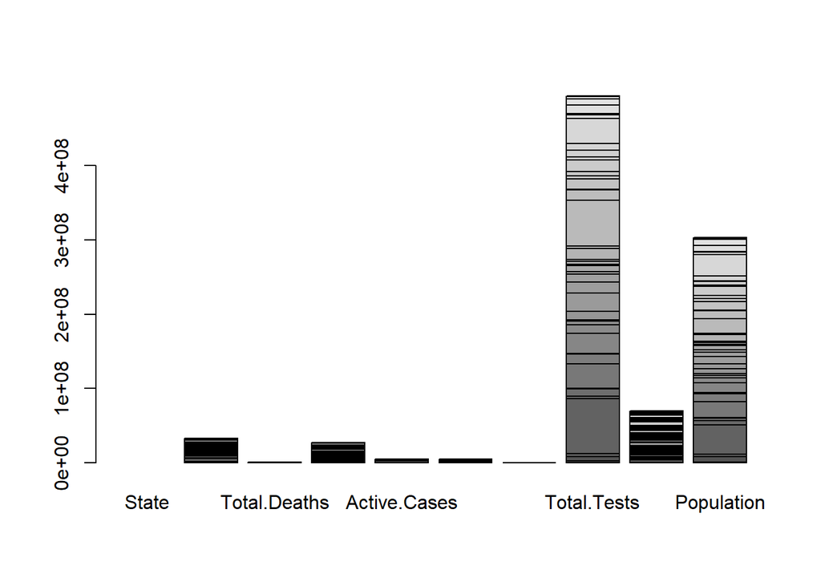

```r
#Stacked Bar Charts
data.na=na.omit(data)
barplot(as.matrix(data.na))
```

Horizontal Bars:

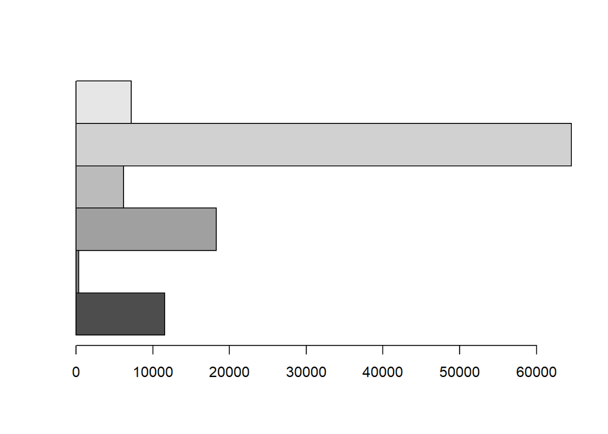

```r
barplot(data.mat, beside = TRUE, horiz = TRUE)
```

The analysis of variance using the aov() command

```r
temp.aov = na.omit(aov(data$Total.Cases ~ data$Total.Deaths, data = data))
temp.aov
```

```
## Call:
##    aov(formula = data$Total.Cases ~ data$Total.Deaths, data = data)
##
## Terms:
##                 data$Total.Deaths    Residuals
## Sum of Squares       2.900405e+13 1.831760e+12
## Deg. of Freedom                 1           48
##
## Residual standard error: 195350.1
## Estimated effects may be unbalanced
```

To see the classic ANOVA table of results, use the summary() command:

```r
summary(temp.aov)
```

```
##                   Df    Sum Sq   Mean Sq F value Pr(>F)
## data$Total.Deaths  1 2.900e+13 2.900e+13     760 <2e-16 ***
## Residuals         48 1.832e+12 3.816e+10
## ---
## Signif. codes:  0 '***' 0.001 '**' 0.01 '*' 0.05 '.' 0.1 ' ' 1
```

Two-Way ANOVA: In a basic one-way ANOVA you have one response variable and one predictor variable, but you may come across a situation in which you have more than one predictor variable, in such cases use two-way ANOVA.

```r
data.aov = aov(Total.Cases ~ Total.Deaths + Population, data = data)
summary(data.aov)
```

```
##              Df    Sum Sq   Mean Sq F value   Pr(>F)
## Total.Deaths  1 2.900e+13 2.900e+13    2993  < 2e-16 ***
## Population    1 1.376e+12 1.376e+12     142 8.33e-16 ***
## Residuals    47 4.555e+11 9.692e+09
## ---
## Signif. codes:  0 '***' 0.001 '**' 0.01 '*' 0.05 '.' 0.1 ' ' 1
```

creating new testCol/testRow for addition as a new column/row to the df object (using rep() command):

```r
testCol = c(rep(data$Total.Cases - data$Total.Deaths, length(data)))
head(testCol)
```

```
## [1]  577574   72606  913135  383081 3919149  570072
```

```r
testRow = c('Albama1', 2100, 3100, 263, 2888, 18,66, 334, 768, 3000)
testRow
```

```
##  [1] "Albama1" "2100"    "3100"    "263"     "2888"    "18"      "66"
##  [8] "334"     "768"     "3000"
```

Adding Rows or Columns:

```r
test = data.frame(data, testCol)
head(test)
```

```
##        State Total.Cases Total.Deaths Total.Recovered Active.Cases
## 1    Alabama      589110        11536              NA           NA
## 2     Alaska       72988          382           67322         5284
## 3    Arizona      931387        18252          879184        33951
## 4   Arkansas      389280         6199          364054        19027
## 5 California     3983692        64543         2105689      1813460
## 6   Colorado      577285         7213          509648        60424
##   Total.Cases.1.mil.population Death.1.mil.population Total.Tests
## 1                       120148                   2353     2906242
## 2                        99772                    522     2509643
## 3                       127960                   2508     5287252
## 4                       128994                   2054     4082199
## 5                       100822                   1633    74176215
## 6                       100245                   1253     3287765
##   Tests.1.mil.population Population testCol
## 1                 592725    4903185  577574
## 2                3430606     731545   72606
## 3                 726399    7278717  913135
## 4                1352705    3017804  383081
## 5                1877298   39512223 3919149
## 6                 570918    5758736  570072
```

```r
test = data
test['testRow',] = testRow
tail(test)
```

```
##                 State Total.Cases Total.Deaths Total.Recovered Active.Cases
## 46           Virginia      699342        11536           58179       629627
## 47         Washington      477723         6172          231097       240454
## 48      West Virginia      167681         2949          162252         2480
## 49          Wisconsin      689284         8295            <NA>         <NA>
## 50            Wyoming       65467          776           63712          979
## testRow       Albama1        2100         3100             263         2888
##         Total.Cases.1.mil.population Death.1.mil.population Total.Tests
## 46                             81933                   1352    10707391
## 47                             62735                    811     8844896
## 48                             93564                   1646     3133703
## 49                            118384                   1425     3660315
## 50                            113116                   1341      822614
## testRow                           18                     66         334
##         Tests.1.mil.population Population
## 46                     1254451    8535519
## 47                     1161526    7614893
## 48                     1748575    1792147
## 49                      628657    5822434
## 50                     1421341     578759
## testRow                    768       3000
```

```r
test = data
test["Test",] = NA
tail(test)
```

```
##              State Total.Cases Total.Deaths Total.Recovered Active.Cases
## 46        Virginia      699342        11536           58179       629627
## 47      Washington      477723         6172          231097       240454
## 48   West Virginia      167681         2949          162252         2480
## 49       Wisconsin      689284         8295              NA           NA
## 50         Wyoming       65467          776           63712          979
## Test          <NA>          NA           NA              NA           NA
##      Total.Cases.1.mil.population Death.1.mil.population Total.Tests
## 46                          81933                   1352    10707391
## 47                          62735                    811     8844896
## 48                          93564                   1646     3133703
## 49                         118384                   1425     3660315
## 50                         113116                   1341      822614
## Test                           NA                     NA          NA
##      Tests.1.mil.population Population
## 46                  1254451    8535519
## 47                  1161526    7614893
## 48                  1748575    1792147
## 49                   628657    5822434
## 50                  1421341     578759
## Test                     NA         NA
```

Column Indexes:

```r
col(data, as.factor = F)
```

```
##       [,1] [,2] [,3] [,4] [,5] [,6] [,7] [,8] [,9] [,10]
##  [1,]    1    2    3    4    5    6    7    8    9    10
##  [2,]    1    2    3    4    5    6    7    8    9    10
##  [3,]    1    2    3    4    5    6    7    8    9    10
##  [4,]    1    2    3    4    5    6    7    8    9    10
##  [5,]    1    2    3    4    5    6    7    8    9    10
##  [6,]    1    2    3    4    5    6    7    8    9    10
##  [7,]    1    2    3    4    5    6    7    8    9    10
##  [8,]    1    2    3    4    5    6    7    8    9    10
##  [9,]    1    2    3    4    5    6    7    8    9    10
## [10,]    1    2    3    4    5    6    7    8    9    10
## [11,]    1    2    3    4    5    6    7    8    9    10
## [12,]    1    2    3    4    5    6    7    8    9    10
## [13,]    1    2    3    4    5    6    7    8    9    10
## [14,]    1    2    3    4    5    6    7    8    9    10
```

[output cut: 36 more lines]

Extracting two columns from data:

```r
x = data[ , 9:10]
head(x)
```

```
##   Tests.1.mil.population Population
## 1                 592725    4903185
## 2                3430606     731545
## 3                 726399    7278717
## 4                1352705    3017804
## 5                1877298   39512223
## 6                 570918    5758736
```

Use the apply() command to apply a function over all the rows or columns of a data frame (or matrix):

```r
#similar to colMean()
apply(data[ , 9:10], 2, mean)
```

```
## Tests.1.mil.population             Population
##                1570324                6550675
```

```r
apply(data[ , 5:10], 2, mean)
```

```
##                 Active.Cases Total.Cases.1.mil.population
##                           NA                    106079.10
##       Death.1.mil.population                  Total.Tests
##                      1725.84                  10464777.54
##       Tests.1.mil.population                   Population
##                   1570324.24                   6550675.48
```

```r
apply(data[ , 9:10], 2, median)
```

```
## Tests.1.mil.population             Population
##                1394970                4558234
```

```r
apply(data[ , 9:10], 2, var)
```

```
## Tests.1.mil.population             Population
##           6.559596e+11           5.460149e+13
```

Using tapply() to Summarize Using a Grouping Variable:

```r
tapply(data$Total.Cases, data$State, FUN = mean)
```

```
##        Alabama         Alaska        Arizona       Arkansas     California
##         589110          72988         931387         389280        3983692
##       Colorado    Connecticut       Delaware        Florida        Georgia
##         577285         355580         111681        2636066        1185571
##         Hawaii          Idaho       Illinois        Indiana           Iowa
##          43227         201352        1425219         774097         410166
##         Kansas       Kentucky      Louisiana          Maine       Maryland
##         334636         486115         552787          70463         469542
##  Massachusetts       Michigan      Minnesota    Mississippi       Missouri
##         721885        1011106         613325         348496         682738
##        Montana       Nebraska         Nevada  New Hampshire     New Jersey
##         116634         228450         358932         100986        1041159
##     New Mexico       New York North Carolina   North Dakota           Ohio
##         211492        2218884        1056699         111699        1131029
##       Oklahoma         Oregon   Pennsylvania   Rhode Island South Carolina
##         486232         221799        1232272         154790         623947
##   South Dakota      Tennessee          Texas           Utah        Vermont
##         125216         900418        3151039         434711          25038
##       Virginia     Washington  West Virginia      Wisconsin        Wyoming
##         699342         477723         167681         689284          65467
```

```r
tapply(data$Total.Deaths, data$State, FUN = mean)
```

```
##        Alabama         Alaska        Arizona       Arkansas     California
##          11536            382          18252           6199          64543
##       Colorado    Connecticut       Delaware        Florida        Georgia
##           7213           8293           1833          39079          21698
##         Hawaii          Idaho       Illinois        Indiana           Iowa
##            537           2203          25930          14012           6183
##         Kansas       Kentucky      Louisiana          Maine       Maryland
##           5266           7348          11026            900           9829
##  Massachusetts       Michigan      Minnesota    Mississippi       Missouri
##          18084          21188           7767           7556          10317
##        Montana       Nebraska         Nevada  New Hampshire     New Jersey
##           1708           2280           5918           1387          26606
##     New Mexico       New York North Carolina   North Dakota           Ohio
##           4414          54259          13670           1539          20492
##       Oklahoma         Oregon   Pennsylvania   Rhode Island South Carolina
##           7485           2863          27957           2740           9915
##   South Dakota      Tennessee          Texas           Utah        Vermont
##           2043          12758          53524           2466            260
##       Virginia     Washington  West Virginia      Wisconsin        Wyoming
##          11536           6172           2949           8295            776
```

```r
tapply(data$Total.Recovered, data$State, FUN = mean)
```

```
##        Alabama         Alaska        Arizona       Arkansas     California
##             NA          67322         879184         364054        2105689
##       Colorado    Connecticut       Delaware        Florida        Georgia
##         509648         341015         108120        2289018        1089121
##         Hawaii          Idaho       Illinois        Indiana           Iowa
##             NA         116853        1365687         736788         368095
##         Kansas       Kentucky      Louisiana          Maine       Maryland
##         312410             NA             NA             NA          11097
##  Massachusetts       Michigan      Minnesota    Mississippi       Missouri
##         702453         872163         601499         317559         577729
##        Montana       Nebraska         Nevada  New Hampshire     New Jersey
##         113585             NA         321902          98861         991814
##     New Mexico       New York North Carolina   North Dakota           Ohio
##         197079        2077953        1012724         109712        1092429
##       Oklahoma         Oregon   Pennsylvania   Rhode Island South Carolina
##         464464         203476        1190693           9475         583708
##   South Dakota      Tennessee          Texas           Utah        Vermont
##         122739         864529        2958075         417384          24234
##       Virginia     Washington  West Virginia      Wisconsin        Wyoming
##          58179         231097         162252             NA          63712
```

```r
tapply(data$Active.Cases, data$State, FUN = mean)
```

```
##        Alabama         Alaska        Arizona       Arkansas     California
##             NA           5284          33951          19027        1813460
##       Colorado    Connecticut       Delaware        Florida        Georgia
##          60424           6272           1728         307969          74752
##         Hawaii          Idaho       Illinois        Indiana           Iowa
##             NA          82296          33602          23297          35888
##         Kansas       Kentucky      Louisiana          Maine       Maryland
##          16960             NA             NA             NA         448616
##  Massachusetts       Michigan      Minnesota    Mississippi       Missouri
##           1348         117755           4059          23381          94692
##        Montana       Nebraska         Nevada  New Hampshire     New Jersey
##           1341             NA          31112            738          22739
##     New Mexico       New York North Carolina   North Dakota           Ohio
##           9999          86672          30305            448          18108
##       Oklahoma         Oregon   Pennsylvania   Rhode Island South Carolina
##          14283          15460          13622         142575          30324
##   South Dakota      Tennessee          Texas           Utah        Vermont
##            434          23131         139440          14861            544
##       Virginia     Washington  West Virginia      Wisconsin        Wyoming
##         629627         240454           2480             NA            979
```

```r
tapply(data$Population, data$State, FUN = mean)
```

```
##        Alabama         Alaska        Arizona       Arkansas     California
##        4903185         731545        7278717        3017804       39512223
##       Colorado    Connecticut       Delaware        Florida        Georgia
##        5758736        3565287         973764       21477737       10617423
##         Hawaii          Idaho       Illinois        Indiana           Iowa
##        1415872        1787065       12671821        6732219        3155070
##         Kansas       Kentucky      Louisiana          Maine       Maryland
##        2913314        4467673        4648794        1344212        6045680
##  Massachusetts       Michigan      Minnesota    Mississippi       Missouri
##        6892503        9986857        5639632        2976149        6137428
##        Montana       Nebraska         Nevada  New Hampshire     New Jersey
##        1068778        1934408        3080156        1359711        8882190
##     New Mexico       New York North Carolina   North Dakota           Ohio
##        2096829       19453561       10488084         762062       11689100
##       Oklahoma         Oregon   Pennsylvania   Rhode Island South Carolina
##        3956971        4217737       12801989        1059361        5148714
##   South Dakota      Tennessee          Texas           Utah        Vermont
##         884659        6829174       28995881        3205958         623989
##       Virginia     Washington  West Virginia      Wisconsin        Wyoming
##        8535519        7614893        1792147        5822434         578759
```

```r
tapply(data$Total.Tests, data$State, FUN = mean)
```

```
##        Alabama         Alaska        Arizona       Arkansas     California
##        2906242        2509643        5287252        4082199       74176215
##       Colorado    Connecticut       Delaware        Florida        Georgia
##        3287765        9944525         754246       33225562       12506402
##         Hawaii          Idaho       Illinois        Indiana           Iowa
##        1865038        1459164       26960921       11270135        5318317
##         Kansas       Kentucky      Louisiana          Maine       Maryland
##        1512666        7234133        8355539        2838766       11317158
##  Massachusetts       Michigan      Minnesota    Mississippi       Missouri
##       24722878       15254738       10670347        3072117        8356808
##        Montana       Nebraska         Nevada  New Hampshire     New Jersey
##        1506498        2123023        3744190        2528241       14691330
##     New Mexico       New York North Carolina   North Dakota           Ohio
##        3827466       61423635       14477619         453933       14120067
##       Oklahoma         Oregon   Pennsylvania   Rhode Island South Carolina
##        4201395        5740690       15099009        4622968        8550617
##   South Dakota      Tennessee          Texas           Utah        Vermont
##         497026        8459184       33997209        5336176        1780906
##       Virginia     Washington  West Virginia      Wisconsin        Wyoming
##       10707391        8844896        3133703        3660315         822614
```

The aggregate() command enables you to compute summary statistics for subsets of a data frame or matrix.

```r
aggregate(data[ , 9:10], by = list(data$State), FUN = mean)
```

```
##           Group.1 Tests.1.mil.population Population
## 1         Alabama                 592725    4903185
## 2          Alaska                3430606     731545
## 3         Arizona                 726399    7278717
## 4        Arkansas                1352705    3017804
## 5      California                1877298   39512223
## 6        Colorado                 570918    5758736
## 7     Connecticut                2789264    3565287
## 8        Delaware                 774568     973764
## 9         Florida                1546977   21477737
## 10        Georgia                1177913   10617423
## 11         Hawaii                1317236    1415872
## 12          Idaho                 816514    1787065
## 13       Illinois                2127628   12671821
## 14        Indiana                1674059    6732219
```

[output cut: 36 more lines]

```r
aggregate(data[ , 2:3], by = list(data$State), FUN = mean)
```

```
##           Group.1 Total.Cases Total.Deaths
## 1         Alabama      589110        11536
## 2          Alaska       72988          382
## 3         Arizona      931387        18252
## 4        Arkansas      389280         6199
## 5      California     3983692        64543
## 6        Colorado      577285         7213
## 7     Connecticut      355580         8293
## 8        Delaware      111681         1833
## 9         Florida     2636066        39079
## 10        Georgia     1185571        21698
## 11         Hawaii       43227          537
## 12          Idaho      201352         2203
## 13       Illinois     1425219        25930
## 14        Indiana      774097        14012
```

[output cut: 36 more lines]

```r
aggregate(data[ , 3:4], by = list(data$State), FUN = mean)
```

```
##           Group.1 Total.Deaths Total.Recovered
## 1         Alabama        11536              NA
## 2          Alaska          382           67322
## 3         Arizona        18252          879184
## 4        Arkansas         6199          364054
## 5      California        64543         2105689
## 6        Colorado         7213          509648
## 7     Connecticut         8293          341015
## 8        Delaware         1833          108120
## 9         Florida        39079         2289018
## 10        Georgia        21698         1089121
## 11         Hawaii          537              NA
## 12          Idaho         2203          116853
## 13       Illinois        25930         1365687
## 14        Indiana        14012          736788
```

[output cut: 36 more lines]

```r
aggregate(data[ , 3:6], by = list(data$State), FUN = mean)
```

```
##           Group.1 Total.Deaths Total.Recovered Active.Cases
## 1         Alabama        11536              NA           NA
## 2          Alaska          382           67322         5284
## 3         Arizona        18252          879184        33951
## 4        Arkansas         6199          364054        19027
## 5      California        64543         2105689      1813460
## 6        Colorado         7213          509648        60424
## 7     Connecticut         8293          341015         6272
## 8        Delaware         1833          108120         1728
## 9         Florida        39079         2289018       307969
## 10        Georgia        21698         1089121        74752
## 11         Hawaii          537              NA           NA
## 12          Idaho         2203          116853        82296
## 13       Illinois        25930         1365687        33602
## 14        Indiana        14012          736788        23297
```

[output cut: 87 more lines]

Using cbind():

```r
aggregate(cbind(data$Total.Cases, data$Total.Recovered), data = data, by = list(data$State), FUN = mean)
```

```
##           Group.1      V1      V2
## 1         Alabama  589110      NA
## 2          Alaska   72988   67322
## 3         Arizona  931387  879184
## 4        Arkansas  389280  364054
## 5      California 3983692 2105689
## 6        Colorado  577285  509648
## 7     Connecticut  355580  341015
## 8        Delaware  111681  108120
## 9         Florida 2636066 2289018
## 10        Georgia 1185571 1089121
## 11         Hawaii   43227      NA
## 12          Idaho  201352  116853
## 13       Illinois 1425219 1365687
## 14        Indiana  774097  736788
```

[output cut: 36 more lines]

```r
aggregate(data$Total.Cases ~ data$State* data$Total.Recovered, data = data, FUN = mean)
```

```
##        data$State data$Total.Recovered data$Total.Cases
## 1    Rhode Island                 9475           154790
## 2        Maryland                11097           469542
## 3         Vermont                24234            25038
## 4        Virginia                58179           699342
## 5         Wyoming                63712            65467
## 6          Alaska                67322            72988
## 7   New Hampshire                98861           100986
## 8        Delaware               108120           111681
## 9    North Dakota               109712           111699
## 10        Montana               113585           116634
## 11          Idaho               116853           201352
## 12   South Dakota               122739           125216
## 13  West Virginia               162252           167681
## 14     New Mexico               197079           211492
```

[output cut: 29 more lines]

```r
aggregate(data$Total.Deaths ~ data$Total.Cases, data = data, FUN = mean)
```

```
##    data$Total.Cases data$Total.Deaths
## 1             25038               260
## 2             43227               537
## 3             65467               776
## 4             70463               900
## 5             72988               382
## 6            100986              1387
## 7            111681              1833
## 8            111699              1539
## 9            116634              1708
## 10           125216              2043
## 11           154790              2740
## 12           167681              2949
## 13           201352              2203
## 14           211492              4414
```

[output cut: 36 more lines]

objects returns a vector of character strings giving the names of the objects in the specified environment:

```r
objects(data)
```

```
##  [1] "Active.Cases"                 "Death.1.mil.population"
##  [3] "Population"                   "State"
##  [5] "Tests.1.mil.population"       "Total.Cases"
##  [7] "Total.Cases.1.mil.population" "Total.Deaths"
##  [9] "Total.Recovered"              "Total.Tests"
```

ls() is similar to object():

```r
ls(data)
```

```
##  [1] "Active.Cases"                 "Death.1.mil.population"
##  [3] "Population"                   "State"
##  [5] "Tests.1.mil.population"       "Total.Cases"
##  [7] "Total.Cases.1.mil.population" "Total.Deaths"
##  [9] "Total.Recovered"              "Total.Tests"
```

Simple lineaR RegreSSion:

```r
datalr = lm(Total.Deaths ~ State, data = data)
datalr
```

```
##
## Call:
## lm(formula = Total.Deaths ~ State, data = data)
##
## Coefficients:
##         (Intercept)          StateAlaska         StateArizona
##           1.154e+04           -1.115e+04            6.716e+03
##       StateArkansas      StateCalifornia        StateColorado
##          -5.337e+03            5.301e+04           -4.323e+03
##    StateConnecticut        StateDelaware         StateFlorida
##          -3.243e+03           -9.703e+03            2.754e+04
##        StateGeorgia          StateHawaii           StateIdaho
##           1.016e+04           -1.100e+04           -9.333e+03
##       StateIllinois         StateIndiana            StateIowa
##           1.439e+04            2.476e+03           -5.353e+03
##         StateKansas        StateKentucky       StateLouisiana
##          -6.270e+03           -4.188e+03           -5.100e+02
##          StateMaine        StateMaryland   StateMassachusetts
##          -1.064e+04           -1.707e+03            6.548e+03
##       StateMichigan       StateMinnesota     StateMississippi
##           9.652e+03           -3.769e+03           -3.980e+03
##       StateMissouri         StateMontana        StateNebraska
##          -1.219e+03           -9.828e+03           -9.256e+03
##         StateNevada   StateNew Hampshire      StateNew Jersey
##          -5.618e+03           -1.015e+04            1.507e+04
##     StateNew Mexico        StateNew York  StateNorth Carolina
##          -7.122e+03            4.272e+04            2.134e+03
##   StateNorth Dakota            StateOhio        StateOklahoma
##          -9.997e+03            8.956e+03           -4.051e+03
##         StateOregon    StatePennsylvania    StateRhode Island
##          -8.673e+03            1.642e+04           -8.796e+03
## StateSouth Carolina    StateSouth Dakota       StateTennessee
##          -1.621e+03           -9.493e+03            1.222e+03
##          StateTexas            StateUtah         StateVermont
##           4.199e+04           -9.070e+03           -1.128e+04
##       StateVirginia      StateWashington   StateWest Virginia
##           4.247e-11           -5.364e+03           -8.587e+03
##      StateWisconsin         StateWyoming
##          -3.241e+03           -1.076e+04
```

```r
cor.test(~ data$Total.Deaths + data$Total.Cases, data = data)
```

```
##
##  Pearson's product-moment correlation
##
## data:  data$Total.Deaths and data$Total.Cases
## t = 27.569, df = 48, p-value < 2.2e-16
## alternative hypothesis: true correlation is not equal to 0
## 95 percent confidence interval:
##  0.9471944 0.9828635
## sample estimates:
##       cor
## 0.9698435
```

Linear Model Results Objects: coefficients can be extracted using the coef() command.

```r
coef(datalr)
```

```
##         (Intercept)         StateAlaska        StateArizona       StateArkansas
##        1.153600e+04       -1.115400e+04        6.716000e+03       -5.337000e+03
##     StateCalifornia       StateColorado    StateConnecticut       StateDelaware
##        5.300700e+04       -4.323000e+03       -3.243000e+03       -9.703000e+03
##        StateFlorida        StateGeorgia         StateHawaii          StateIdaho
##        2.754300e+04        1.016200e+04       -1.099900e+04       -9.333000e+03
##       StateIllinois        StateIndiana           StateIowa         StateKansas
##        1.439400e+04        2.476000e+03       -5.353000e+03       -6.270000e+03
##       StateKentucky      StateLouisiana          StateMaine       StateMaryland
##       -4.188000e+03       -5.100000e+02       -1.063600e+04       -1.707000e+03
##  StateMassachusetts       StateMichigan      StateMinnesota    StateMississippi
##        6.548000e+03        9.652000e+03       -3.769000e+03       -3.980000e+03
##       StateMissouri        StateMontana       StateNebraska         StateNevada
##       -1.219000e+03       -9.828000e+03       -9.256000e+03       -5.618000e+03
##  StateNew Hampshire     StateNew Jersey     StateNew Mexico       StateNew York
##       -1.014900e+04        1.507000e+04       -7.122000e+03        4.272300e+04
## StateNorth Carolina   StateNorth Dakota           StateOhio       StateOklahoma
##        2.134000e+03       -9.997000e+03        8.956000e+03       -4.051000e+03
##         StateOregon   StatePennsylvania   StateRhode Island StateSouth Carolina
##       -8.673000e+03        1.642100e+04       -8.796000e+03       -1.621000e+03
##   StateSouth Dakota      StateTennessee          StateTexas           StateUtah
##       -9.493000e+03        1.222000e+03        4.198800e+04       -9.070000e+03
##        StateVermont       StateVirginia     StateWashington  StateWest Virginia
##       -1.127600e+04        4.246735e-11       -5.364000e+03       -8.587000e+03
##      StateWisconsin        StateWyoming
##       -3.241000e+03       -1.076000e+04
```

Fitted Values

```r
head(fitted(datalr))
```

```
##     1     2     3     4     5     6
## 11536   382 18252  6199 64543  7213
```

Formula

```r
formula(datalr)
```

```
## Total.Deaths ~ State
```

```r
datalr$call
```

```
## lm(formula = Total.Deaths ~ State, data = data)
```

```r
formula(data)
```

```
## State ~ Total.Cases + Total.Deaths + Total.Recovered + Active.Cases +
##     Total.Cases.1.mil.population + Death.1.mil.population + Total.Tests +
##     Tests.1.mil.population + Population
```

```r
data.m = apply(data[,9:10], 2, mean)
data.m
```

```
## Tests.1.mil.population             Population
##                1570324                6550675
```

```r
data.sum = apply(data[,9:10], 2, sum)
data.sum
```

```
## Tests.1.mil.population             Population
##               78516212              327533774
```

```r
data.sd = apply(data[ , 9:10], 2, sd)
data.sd
```

```
## Tests.1.mil.population             Population
##               809913.3              7389281.8
```

```r
data.1 = data.sum/data.m
data.1
```

```
## Tests.1.mil.population             Population
##                     50                     50
```

```r
data.se = data.sd / sqrt(data.1)
data.se
```

```
## Tests.1.mil.population             Population
##                 114539                1045002
```

```r
data.m + data.se
```

```
## Tests.1.mil.population             Population
##                1684863                7595678
```

```r
max(data.m + data.se)
```

```
## [1] 7595678
```

```r
data.max = round(max(data.m + data.se) + 0.5, 0)
data.max
```

```
## [1] 7595678
```

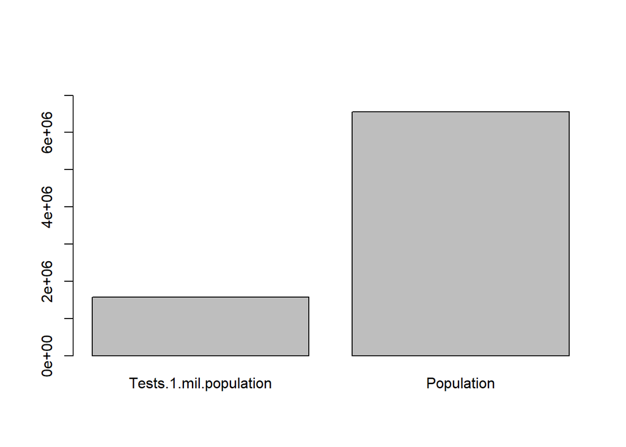

```r
bplt = barplot(data.m, ylim = c(0, data.max))
```

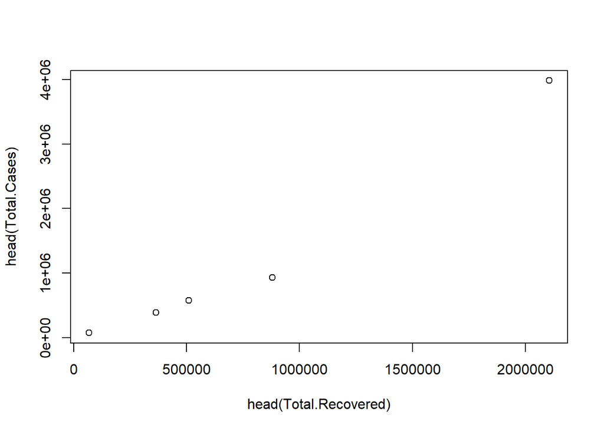

```r
 plot(head(Total.Cases) ~ head(Total.Recovered), data = data)
```

Polynomial Regression:

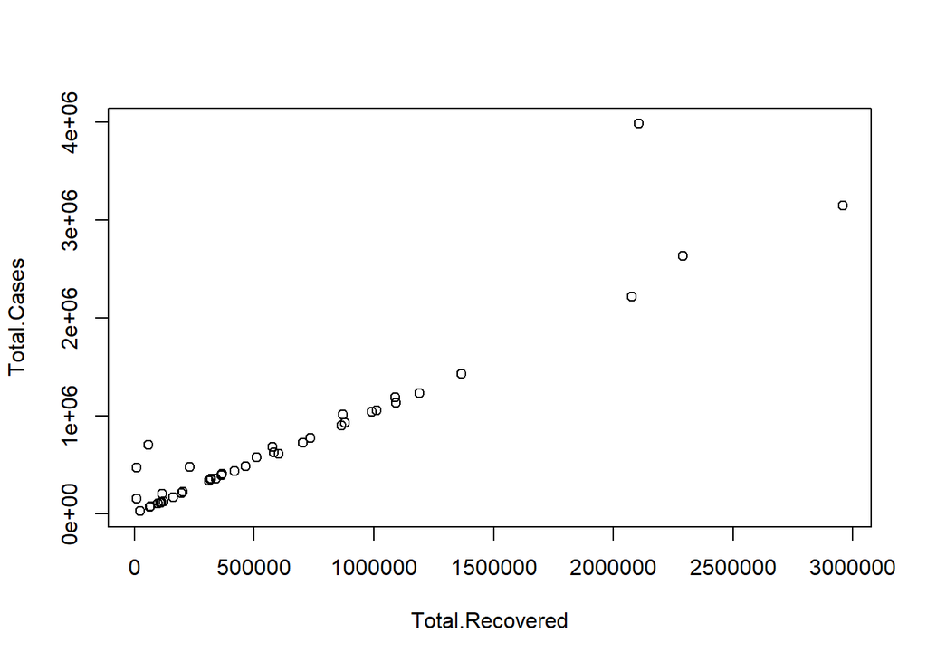

```r
 plot(Total.Cases ~ Total.Recovered, data = data)
```

```r
data.lm = lm( Total.Cases ~ Total.Recovered + I(Total.Recovered^2), data = data)
summary(data.lm)
```

```
##
## Call:
## lm(formula = Total.Cases ~ Total.Recovered + I(Total.Recovered^2),
##     data = data)
##
## Residuals:
##     Min      1Q  Median      3Q     Max
## -480793  -71374  -57700  -35682 1503702
##
## Coefficients:
##                       Estimate Std. Error t value Pr(>|t|)
## (Intercept)          6.125e+04  7.706e+04   0.795    0.431
## Total.Recovered      1.004e+00  1.883e-01   5.333 4.08e-06 ***
## I(Total.Recovered^2) 6.851e-08  7.400e-08   0.926    0.360
## ---
## Signif. codes:  0 '***' 0.001 '**' 0.01 '*' 0.05 '.' 0.1 ' ' 1
##
## Residual standard error: 284200 on 40 degrees of freedom
##   (7 observations deleted due to missingness)
## Multiple R-squared:  0.8908, Adjusted R-squared:  0.8853
## F-statistic: 163.1 on 2 and 40 DF,  p-value: < 2.2e-16
```

Diagnostic Plots:

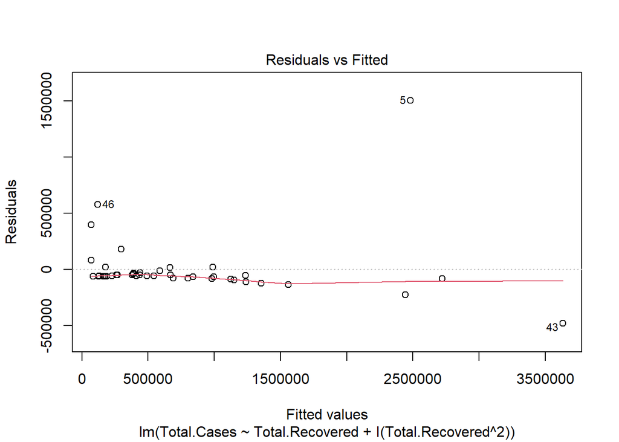

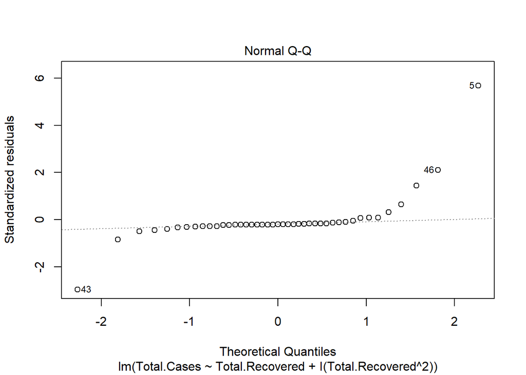

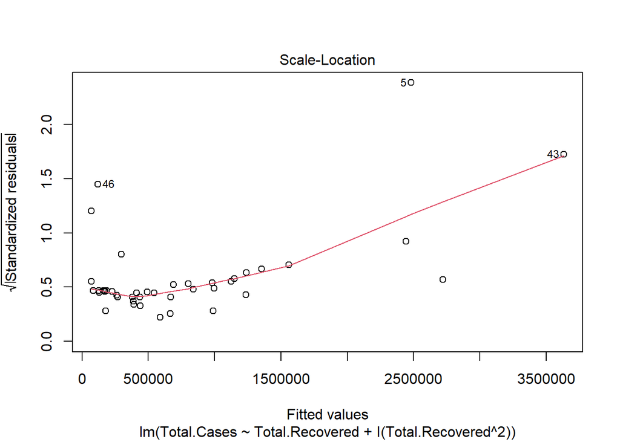

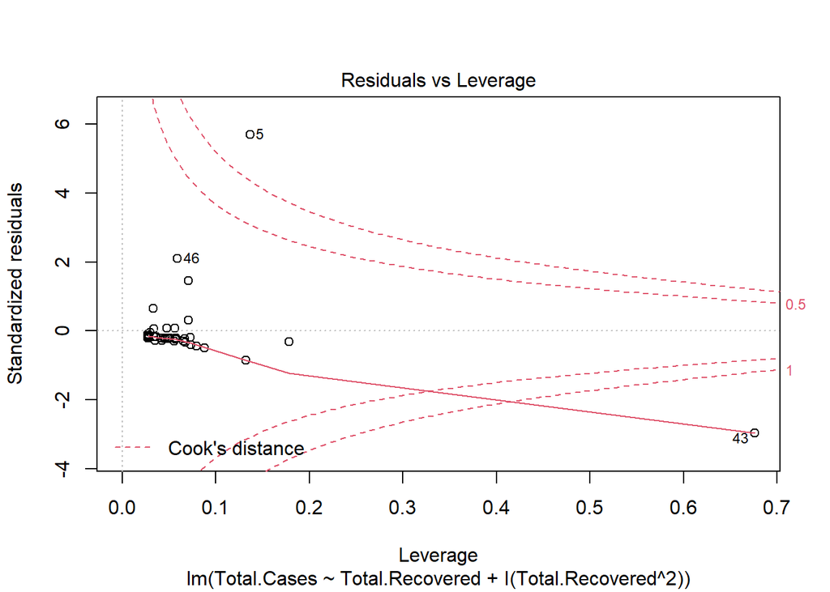

```r
plot(data.lm)
```

Creating Mathematical Expressions:

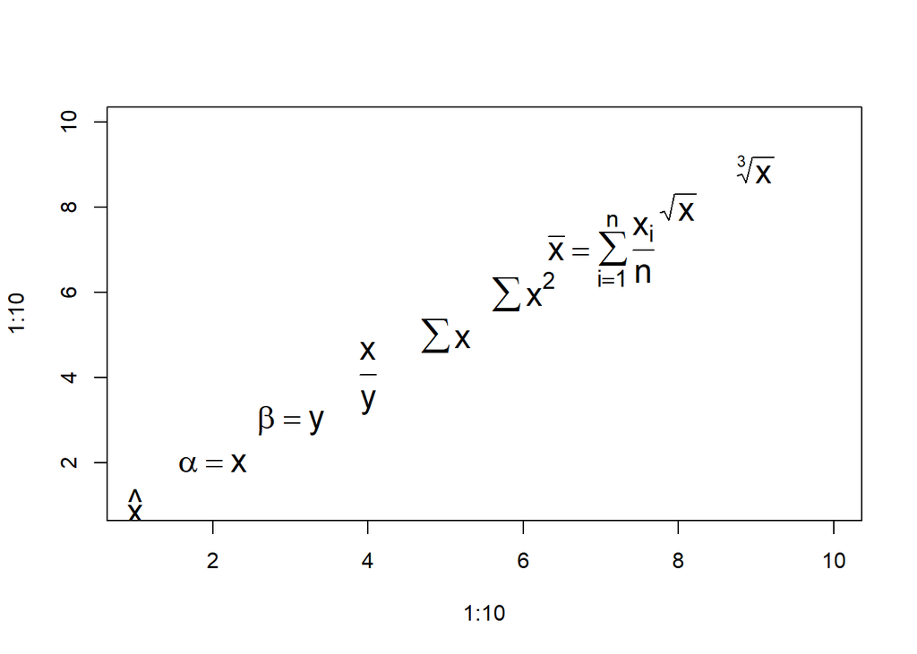

```r
plot(1:10, 1:10, type = 'n')
opt = par(cex = 1.5)
text(1, 1, expression(hat(x)))
text(2, 2, expression(alpha==x))
text(3, 3, expression(beta==y))
text(4, 4, expression(frac(x, y)))
text(5, 5, expression(sum(x)))
text(6, 6, expression(sum(x^2)))
text(7, 7, expression(bar(x) == sum(frac(x[i], n), i==1, n)))
text(8, 8, expression(sqrt(x)))
text(9, 9, expression(sqrt(x, 3)))
```